# student_performance-Copy1

|  | gender | race/ethnicity | parental level of education | lunch | test preparation course | math score | reading score | writing score |
| --- | --- | --- | --- | --- | --- | --- | --- | --- |
| 0 | female | group B | bachelor's degree | standard | none | 72 | 72 | 74 |
| 1 | female | group C | some college | standard | completed | 69 | 90 | 88 |
| 2 | female | group B | master's degree | standard | none | 90 | 95 | 93 |
| 3 | male | group A | associate's degree | free/reduced | none | 47 | 57 | 44 |
| 4 | male | group C | some college | standard | none | 76 | 78 | 75 |

|  | gender | race/ethnicity | parent_education | lunch | prep | math | reading | writing |
| --- | --- | --- | --- | --- | --- | --- | --- | --- |
| 0 | female | group B | bachelor's degree | standard | none | 72 | 72 | 74 |
| 1 | female | group C | some college | standard | completed | 69 | 90 | 88 |
| 2 | female | group B | master's degree | standard | none | 90 | 95 | 93 |
| 3 | male | group A | associate's degree | free/reduced | none | 47 | 57 | 44 |
| 4 | male | group C | some college | standard | none | 76 | 78 | 75 |

|  | gender | race/ethnicity | parent_education | lunch | prep | math | reading | writing |
| --- | --- | --- | --- | --- | --- | --- | --- | --- |
| 0 | female | group B | bachelor's degree | standard | none | 72 | 72 | 74 |
| 1 | female | group C | some college | standard | completed | 69 | 90 | 88 |
| 2 | female | group B | master's degree | standard | none | 90 | 95 | 93 |
| 3 | male | group A | associate's degree | free/reduced | none | 47 | 57 | 44 |
| 4 | male | group C | some college | standard | none | 76 | 78 | 75 |
| ... | ... | ... | ... | ... | ... | ... | ... | ... |
| 995 | female | group E | master's degree | standard | completed | 88 | 99 | 95 |
| 996 | male | group C | high school | free/reduced | none | 62 | 55 | 55 |
| 997 | female | group C | high school | free/reduced | completed | 59 | 71 | 65 |
| 998 | female | group D | some college | standard | completed | 68 | 78 | 77 |
| 999 | female | group D | some college | free/reduced | none | 77 | 86 | 86 |

1000 rows × 8 columns

# lets drop the colomn of Ubudehe because its data are not corresponding to the Ubudehe know in Rwanda

|  | gender | parent_education | lunch | prep | math | reading | writing |
| --- | --- | --- | --- | --- | --- | --- | --- |
| 0 | female | bachelor's degree | standard | none | 72 | 72 | 74 |
| 1 | female | some college | standard | completed | 69 | 90 | 88 |
| 2 | female | master's degree | standard | none | 90 | 95 | 93 |
| 3 | male | associate's degree | free/reduced | none | 47 | 57 | 44 |
| 4 | male | some college | standard | none | 76 | 78 | 75 |
| ... | ... | ... | ... | ... | ... | ... | ... |
| 995 | female | master's degree | standard | completed | 88 | 99 | 95 |
| 996 | male | high school | free/reduced | none | 62 | 55 | 55 |
| 997 | female | high school | free/reduced | completed | 59 | 71 | 65 |
| 998 | female | some college | standard | completed | 68 | 78 | 77 |
| 999 | female | some college | free/reduced | none | 77 | 86 | 86 |

1000 rows × 7 columns

|  | math | reading | writing |
| --- | --- | --- | --- |
| count | 1000.00000 | 1000.000000 | 1000.000000 |
| mean | 66.08900 | 69.169000 | 68.054000 |
| std | 15.16308 | 14.600192 | 15.195657 |
| min | 0.00000 | 17.000000 | 10.000000 |
| 25% | 57.00000 | 59.000000 | 57.750000 |
| 50% | 66.00000 | 70.000000 | 69.000000 |
| 75% | 77.00000 | 79.000000 | 79.000000 |
| max | 100.00000 | 100.000000 | 100.000000 |

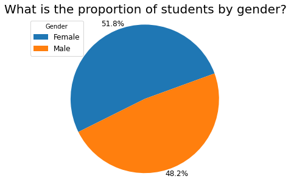

The percentage of females is slightly higher in this dataset.

# What is the parents' level of education?

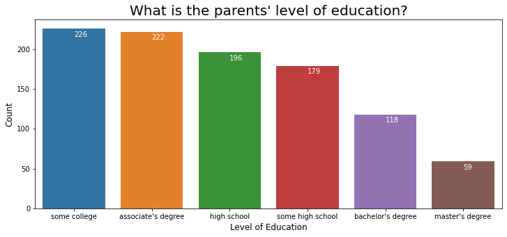

Most of the parents went to college or have an associate's degree

# Which lunch type is preferred?

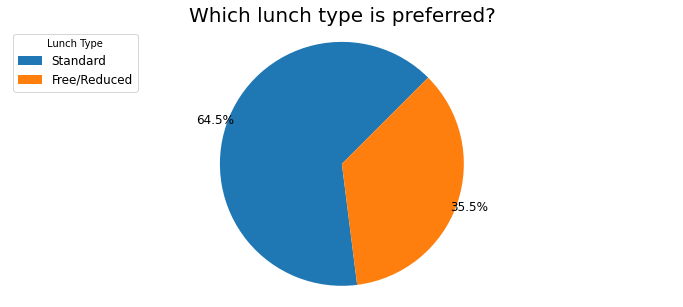

The standard lunch is the most popular.

# Did the students take the test preparation course?

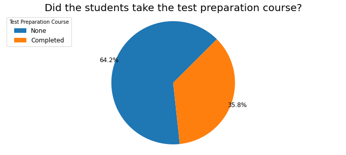

Most students did not take the test preparation course.

# How are scores distributed?

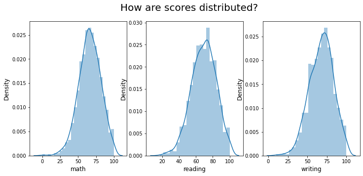

The scores are slightly left skewed.

# How are grades distributed?

Let's create a USA GPA column that will be useful throughout the analysis.

Next, we are going to create a column with the number of exams the students passed

|  | math | Math GPA | reading | Reading GPA | writing | Writing GPA | Exams Passed |
| --- | --- | --- | --- | --- | --- | --- | --- |
| 0 | 72 | C | 72 | C | 74 | C | 3 |
| 1 | 69 | D | 90 | A | 88 | B | 3 |
| 2 | 90 | A | 95 | A | 93 | A | 3 |
| 3 | 47 | F | 57 | F | 44 | F | 0 |
| 4 | 76 | C | 78 | C | 75 | C | 3 |

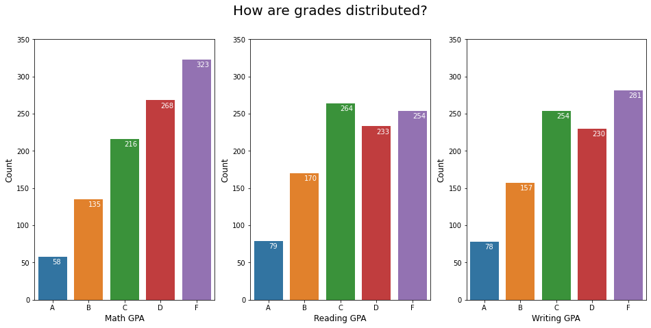

Math had the worse grades, while reading had the best. 323 students failed at math, while 254 failed at reading and 281 failed at writing.

# How many students passed in all exams?

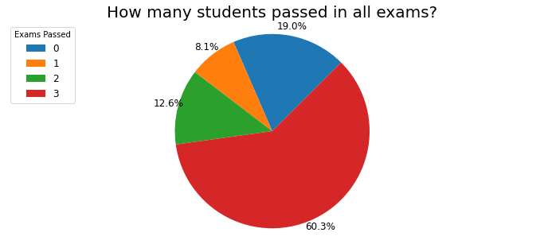

Most students passed all three exams. There were more students failing all exams than failing one or two.

# Which gender did better at Math?

Before plotting sunburst charts to see which gender got better grades in which subjects, we're writing some auxiliary code

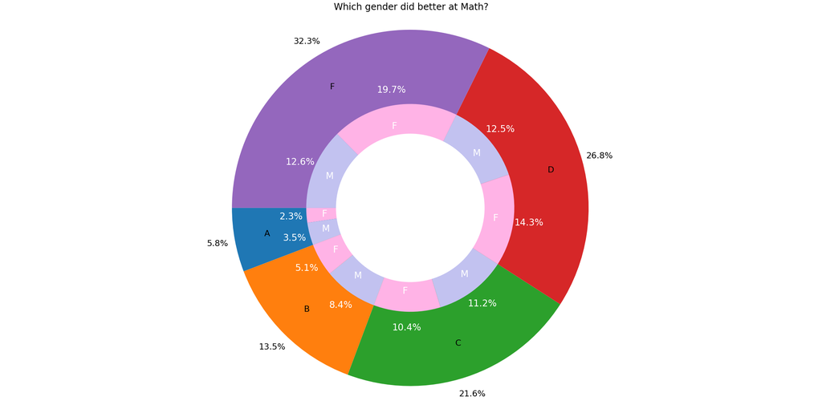

More males got As, Bs, and Cs, so they did better in math.

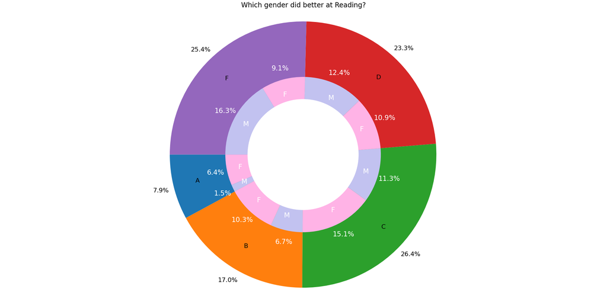

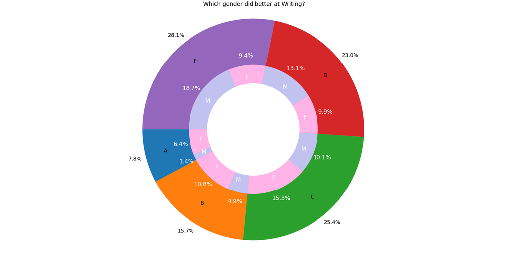

The plots for reading and writing are similar, females did better.

# How are the different scores related?

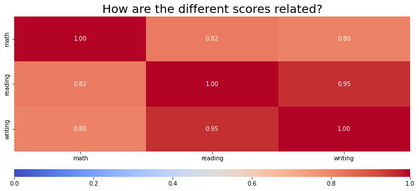

Reading scores and writing scores are highly correlated so a student who reads well also writes well. Math scores have lower correlations with other subjects, so we can't be so sure that if a student is good at math he is good at other subjects or vice versa.

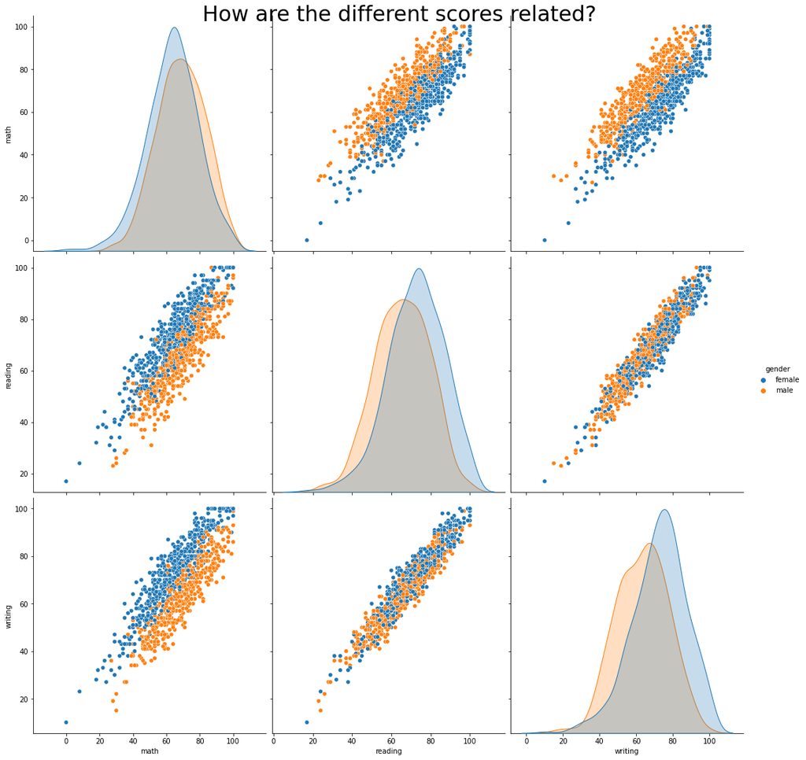

It appears that the scores of the different subjects increase linearly with each other. Most students had between 40 and 90 (about 90%) in the three subjects.

# How do gender and parental level of education influence scores?

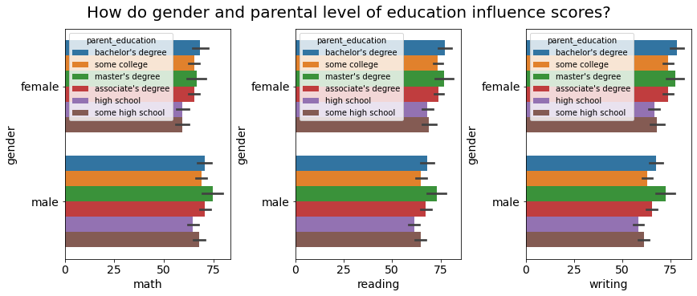

Students whose parents are better educated (Bachelor's and Master's) got better grades in all subjects. Plus, it seems that parents with a master's degree have more influence on male students' grades. If the parental level of education is "High School" and "Some High School" the students got lower scores.

# How do gender and lunch type influence scores?

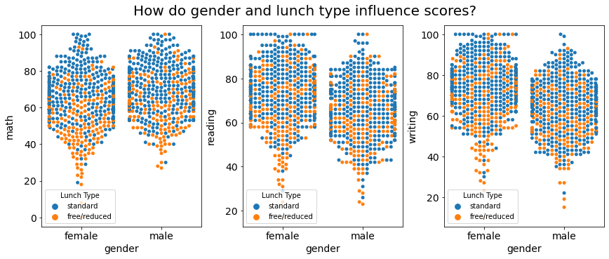

As expected, well-nourished students learn better.

# How do gender and test preparation course influence scores?

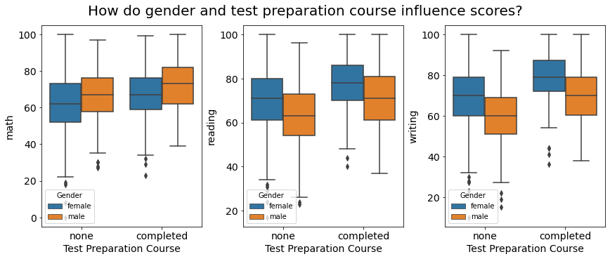

It's clear that preparation pays off. However, there are some outliers. Some students performed well even when they did not complete test preparation. The opposite is also true.

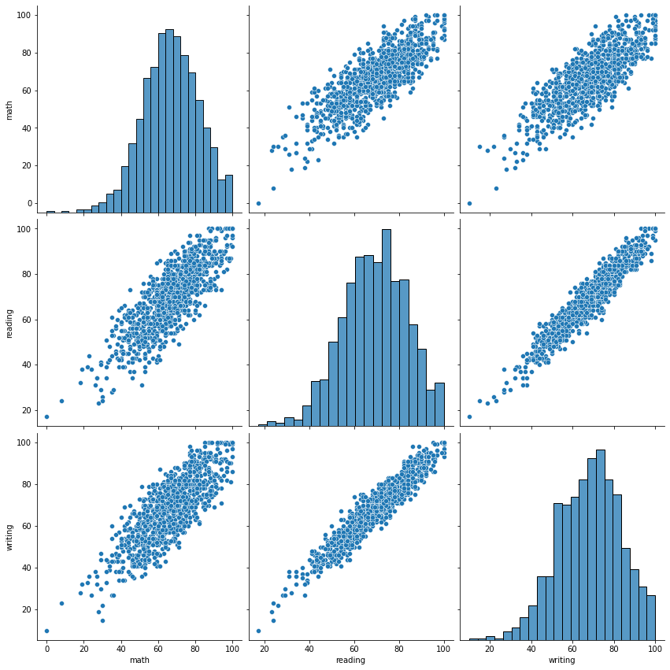

```
gender              object
race/ethnicity      object
parent_education    object
lunch               object
prep                object
math                 int64
reading              int64
writing              int64
Math GPA            object
Reading GPA         object
Writing GPA         object
Exams Passed         int64
dtype: object
```

```
The Probability of Students Passing in all the Subjects is 93.90 %
```

[output not shown]

```
Sample mean for Math Scores: 63.12
Population mean for Math Scores: 66.089

Sample mean for Reading Scores: 68.5
Population mean for Reading Scores: 69.169

Sample mean for Writing Scores: 63.12
Population mean for Writing Scores: 68.054
```

```
z-critical value:  1.6448536269514722
Confidence interval: (64.82729483328328, 66.40470516671672)
True mean: 66.089
```

```
z-critical value:  1.6448536269514722
Confidence interval: (67.75757337011645, 69.27642662988355)
True mean: 69.169
```

```
z-critical value:  1.6448536269514722
Confidence interval: (66.80960035030861, 68.39039964969137)
True mean: 68.054
```

Grouping Operations

|  | gender | race/ethnicity | parent_education | lunch | prep | math | reading | writing | Math GPA | Reading GPA | Writing GPA | Exams Passed |
| --- | --- | --- | --- | --- | --- | --- | --- | --- | --- | --- | --- | --- |
| 114 | female | group E | bachelor's degree | standard | completed | 99 | 100 | 100 | A | A | A | 3 |
| 165 | female | group C | bachelor's degree | standard | completed | 96 | 100 | 100 | A | A | A | 3 |
| 179 | female | group D | some high school | standard | completed | 97 | 100 | 100 | A | A | A | 3 |
| 451 | female | group E | some college | standard | none | 100 | 92 | 97 | A | A | A | 3 |
| 458 | female | group E | bachelor's degree | standard | none | 100 | 100 | 100 | A | A | A | 3 |
| 546 | female | group A | some high school | standard | completed | 92 | 100 | 97 | A | A | A | 3 |
| 566 | female | group E | bachelor's degree | free/reduced | completed | 92 | 100 | 100 | A | A | A | 3 |
| 594 | female | group C | bachelor's degree | standard | completed | 92 | 100 | 99 | A | A | A | 3 |
| 685 | female | group E | master's degree | standard | completed | 94 | 99 | 100 | A | A | A | 3 |
| 712 | female | group D | some college | standard | none | 98 | 100 | 99 | A | A | A | 3 |
| 717 | female | group C | associate's degree | standard | completed | 96 | 96 | 99 | A | A | A | 3 |
| 855 | female | group B | bachelor's degree | standard | none | 97 | 97 | 96 | A | A | A | 3 |
| 886 | female | group E | associate's degree | standard | completed | 93 | 100 | 95 | A | A | A | 3 |
| 903 | female | group D | bachelor's degree | free/reduced | completed | 93 | 100 | 100 | A | A | A | 3 |
| 957 | female | group D | master's degree | standard | none | 92 | 100 | 100 | A | A | A | 3 |
| 962 | female | group E | associate's degree | standard | none | 100 | 100 | 100 | A | A | A | 3 |
| 979 | female | group C | associate's degree | standard | none | 91 | 95 | 94 | A | A | A | 3 |

|  | gender | parent_education | lunch | prep | math | reading | writing |
| --- | --- | --- | --- | --- | --- | --- | --- |
| 0 | female | bachelor's degree | standard | none | 72 | 72 | 74 |
| 1 | female | some college | standard | completed | 69 | 90 | 88 |
| 2 | female | master's degree | standard | none | 90 | 95 | 93 |
| 3 | male | associate's degree | free/reduced | none | 47 | 57 | 44 |
| 4 | male | some college | standard | none | 76 | 78 | 75 |
| ... | ... | ... | ... | ... | ... | ... | ... |
| 995 | female | master's degree | standard | completed | 88 | 99 | 95 |
| 996 | male | high school | free/reduced | none | 62 | 55 | 55 |
| 997 | female | high school | free/reduced | completed | 59 | 71 | 65 |
| 998 | female | some college | standard | completed | 68 | 78 | 77 |
| 999 | female | some college | free/reduced | none | 77 | 86 | 86 |

1000 rows × 7 columns

|  | gender | race/ethnicity | parent_education | lunch | prep | math | reading | writing | Math GPA | Reading GPA | Writing GPA | Exams Passed |
| --- | --- | --- | --- | --- | --- | --- | --- | --- | --- | --- | --- | --- |
| 0 | female | group B | bachelor's degree | standard | none | 72 | 72 | 74 | C | C | C | 3 |
| 1 | female | group C | some college | standard | completed | 69 | 90 | 88 | D | A | B | 3 |
| 2 | female | group B | master's degree | standard | none | 90 | 95 | 93 | A | A | A | 3 |
| 3 | male | group A | associate's degree | free/reduced | none | 47 | 57 | 44 | F | F | F | 0 |
| 4 | male | group C | some college | standard | none | 76 | 78 | 75 | C | C | C | 3 |
| ... | ... | ... | ... | ... | ... | ... | ... | ... | ... | ... | ... | ... |
| 995 | female | group E | master's degree | standard | completed | 88 | 99 | 95 | B | A | A | 3 |
| 996 | male | group C | high school | free/reduced | none | 62 | 55 | 55 | D | F | F | 1 |
| 997 | female | group C | high school | free/reduced | completed | 59 | 71 | 65 | F | C | D | 2 |
| 998 | female | group D | some college | standard | completed | 68 | 78 | 77 | D | C | C | 3 |
| 999 | female | group D | some college | free/reduced | none | 77 | 86 | 86 | C | B | B | 3 |

1000 rows × 12 columns

|  | gender | parent_education | lunch | prep | math | reading | writing |
| --- | --- | --- | --- | --- | --- | --- | --- |
| 0 | female | bachelor's degree | standard | none | 72 | 72 | 74 |
| 1 | female | some college | standard | completed | 69 | 90 | 88 |
| 2 | female | master's degree | standard | none | 90 | 95 | 93 |
| 3 | male | associate's degree | free/reduced | none | 47 | 57 | 44 |
| 4 | male | some college | standard | none | 76 | 78 | 75 |
| ... | ... | ... | ... | ... | ... | ... | ... |
| 995 | female | master's degree | standard | completed | 88 | 99 | 95 |
| 996 | male | high school | free/reduced | none | 62 | 55 | 55 |
| 997 | female | high school | free/reduced | completed | 59 | 71 | 65 |
| 998 | female | some college | standard | completed | 68 | 78 | 77 |
| 999 | female | some college | free/reduced | none | 77 | 86 | 86 |

1000 rows × 7 columns

|  | gender | parent_education | lunch | prep | math | reading | writing | Math GPA | Reading GPA | Writing GPA | Exams Passed |
| --- | --- | --- | --- | --- | --- | --- | --- | --- | --- | --- | --- |
| 0 | female | bachelor's degree | standard | none | 72 | 72 | 74 | C | C | C | 3 |
| 1 | female | some college | standard | completed | 69 | 90 | 88 | D | A | B | 3 |
| 2 | female | master's degree | standard | none | 90 | 95 | 93 | A | A | A | 3 |
| 3 | male | associate's degree | free/reduced | none | 47 | 57 | 44 | F | F | F | 0 |
| 4 | male | some college | standard | none | 76 | 78 | 75 | C | C | C | 3 |
| ... | ... | ... | ... | ... | ... | ... | ... | ... | ... | ... | ... |
| 995 | female | master's degree | standard | completed | 88 | 99 | 95 | B | A | A | 3 |
| 996 | male | high school | free/reduced | none | 62 | 55 | 55 | D | F | F | 1 |
| 997 | female | high school | free/reduced | completed | 59 | 71 | 65 | F | C | D | 2 |
| 998 | female | some college | standard | completed | 68 | 78 | 77 | D | C | C | 3 |
| 999 | female | some college | free/reduced | none | 77 | 86 | 86 | C | B | B | 3 |

1000 rows × 11 columns

|  | gender | parent_education | lunch | prep | math | reading | writing | Reading GPA | Writing GPA | Exams Passed |
| --- | --- | --- | --- | --- | --- | --- | --- | --- | --- | --- |
| 0 | female | bachelor's degree | standard | none | 72 | 72 | 74 | C | C | 3 |
| 1 | female | some college | standard | completed | 69 | 90 | 88 | A | B | 3 |
| 2 | female | master's degree | standard | none | 90 | 95 | 93 | A | A | 3 |
| 3 | male | associate's degree | free/reduced | none | 47 | 57 | 44 | F | F | 0 |
| 4 | male | some college | standard | none | 76 | 78 | 75 | C | C | 3 |
| ... | ... | ... | ... | ... | ... | ... | ... | ... | ... | ... |
| 995 | female | master's degree | standard | completed | 88 | 99 | 95 | A | A | 3 |
| 996 | male | high school | free/reduced | none | 62 | 55 | 55 | F | F | 1 |
| 997 | female | high school | free/reduced | completed | 59 | 71 | 65 | C | D | 2 |
| 998 | female | some college | standard | completed | 68 | 78 | 77 | C | C | 3 |
| 999 | female | some college | free/reduced | none | 77 | 86 | 86 | B | B | 3 |

1000 rows × 10 columns

|  | gender | parent_education | lunch | prep | math | reading | writing | Writing GPA | Exams Passed |
| --- | --- | --- | --- | --- | --- | --- | --- | --- | --- |
| 0 | female | bachelor's degree | standard | none | 72 | 72 | 74 | C | 3 |
| 1 | female | some college | standard | completed | 69 | 90 | 88 | B | 3 |
| 2 | female | master's degree | standard | none | 90 | 95 | 93 | A | 3 |
| 3 | male | associate's degree | free/reduced | none | 47 | 57 | 44 | F | 0 |
| 4 | male | some college | standard | none | 76 | 78 | 75 | C | 3 |
| ... | ... | ... | ... | ... | ... | ... | ... | ... | ... |
| 995 | female | master's degree | standard | completed | 88 | 99 | 95 | A | 3 |
| 996 | male | high school | free/reduced | none | 62 | 55 | 55 | F | 1 |
| 997 | female | high school | free/reduced | completed | 59 | 71 | 65 | D | 2 |
| 998 | female | some college | standard | completed | 68 | 78 | 77 | C | 3 |
| 999 | female | some college | free/reduced | none | 77 | 86 | 86 | B | 3 |

1000 rows × 9 columns

|  | gender | parent_education | lunch | prep | math | reading | writing | Exams Passed |
| --- | --- | --- | --- | --- | --- | --- | --- | --- |
| 0 | female | bachelor's degree | standard | none | 72 | 72 | 74 | 3 |
| 1 | female | some college | standard | completed | 69 | 90 | 88 | 3 |
| 2 | female | master's degree | standard | none | 90 | 95 | 93 | 3 |
| 3 | male | associate's degree | free/reduced | none | 47 | 57 | 44 | 0 |
| 4 | male | some college | standard | none | 76 | 78 | 75 | 3 |
| ... | ... | ... | ... | ... | ... | ... | ... | ... |
| 995 | female | master's degree | standard | completed | 88 | 99 | 95 | 3 |
| 996 | male | high school | free/reduced | none | 62 | 55 | 55 | 1 |
| 997 | female | high school | free/reduced | completed | 59 | 71 | 65 | 2 |
| 998 | female | some college | standard | completed | 68 | 78 | 77 | 3 |
| 999 | female | some college | free/reduced | none | 77 | 86 | 86 | 3 |

1000 rows × 8 columns

| gender | math min | math median | math max | reading min | reading median | reading max | writing min | writing median | writing max | Exams Passed min | Exams Passed median | Exams Passed max |
| --- | --- | --- | --- | --- | --- | --- | --- | --- | --- | --- | --- | --- |
| female | 0 | 65.0 | 100 | 17 | 73.0 | 100 | 10 | 74.0 | 100 | 0 | 3.0 | 3 |
| male | 27 | 69.0 | 100 | 23 | 66.0 | 100 | 15 | 64.0 | 100 | 0 | 3.0 | 3 |

| lunch | gender | math | writing | reading |
| --- | --- | --- | --- | --- |
| free/reduced | female | 57.0 | 68.0 | 67.0 |
|  | male | 62.0 | 59.0 | 61.0 |
| standard | female | 67.0 | 76.0 | 75.0 |
|  | male | 72.0 | 67.0 | 67.5 |

# Data Visualizations

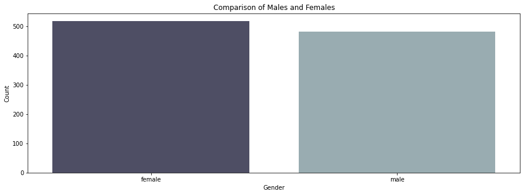

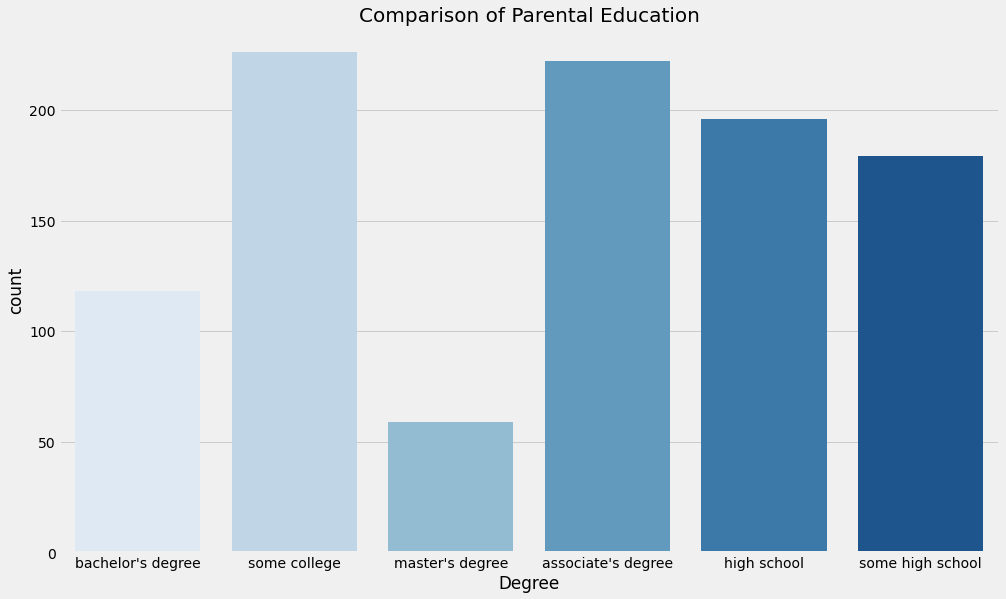

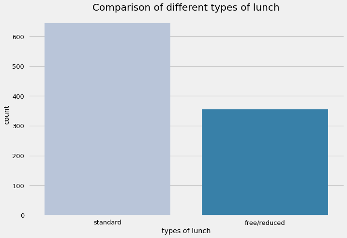

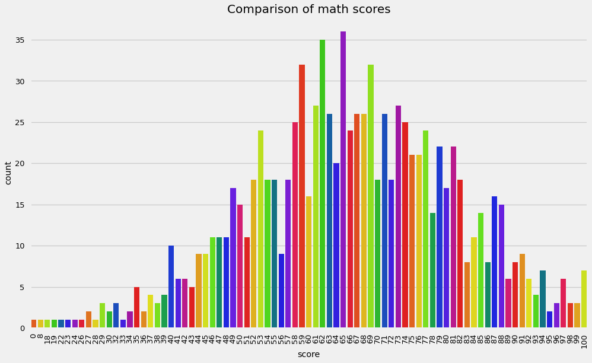

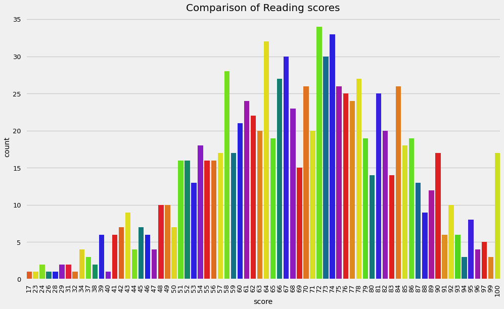

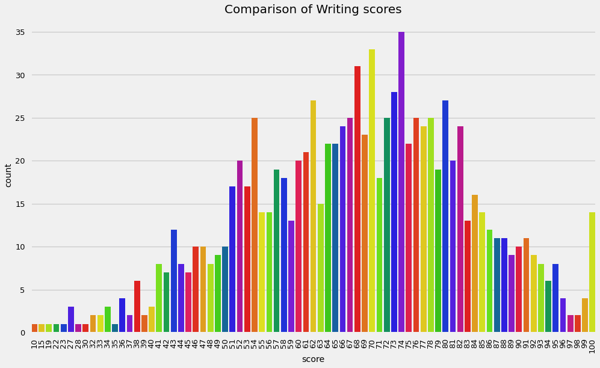

```
'parent_education'
```

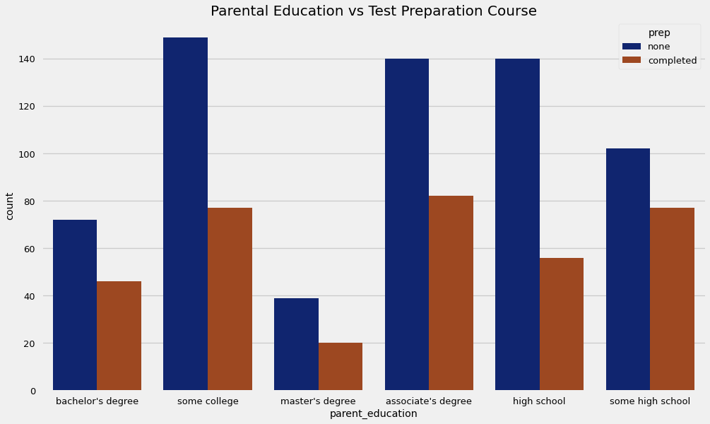

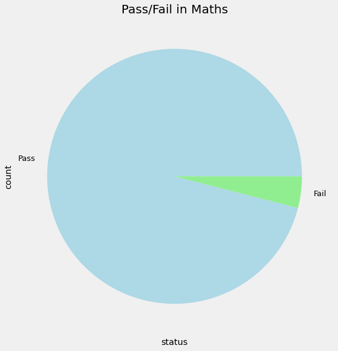

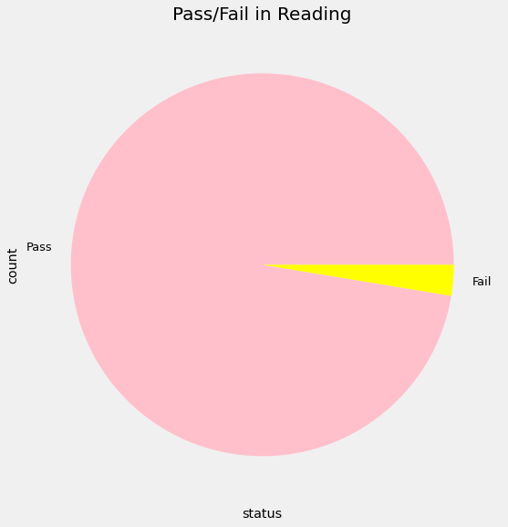

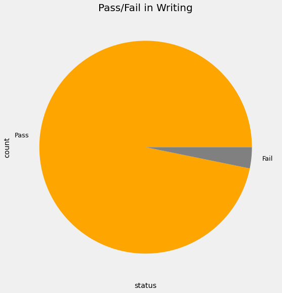

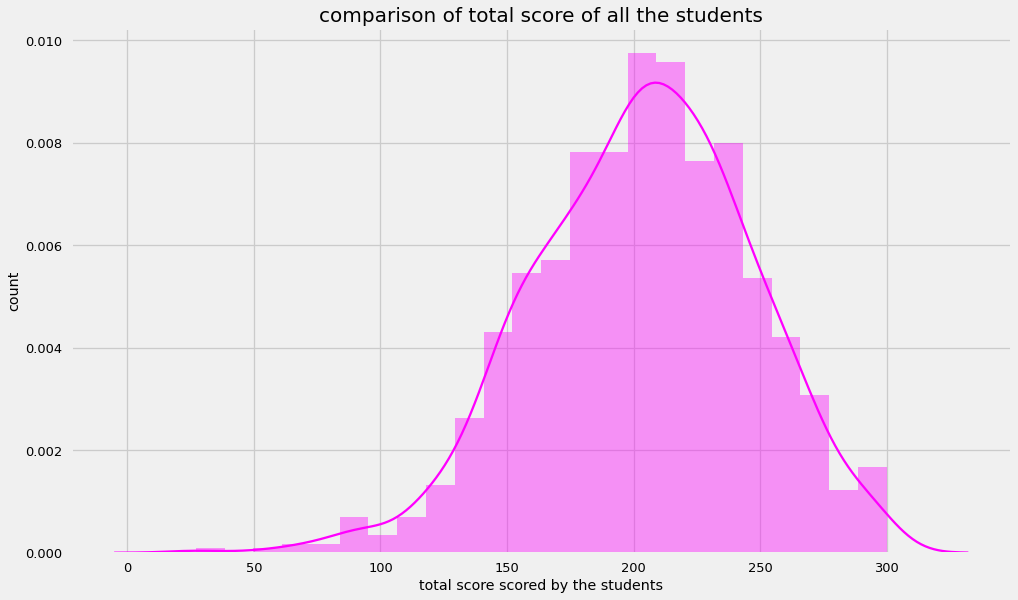

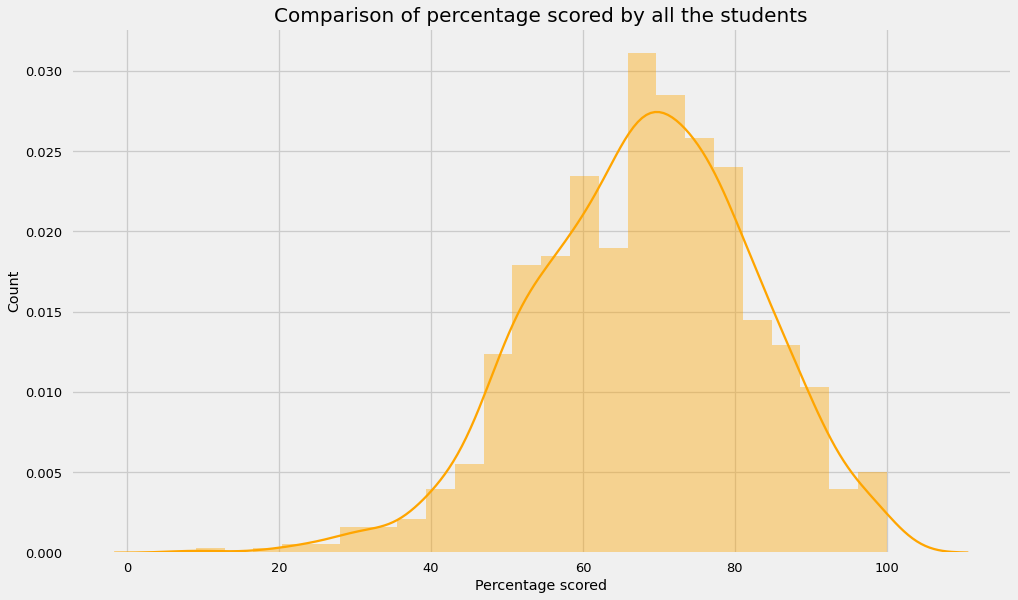